# Projet anxiete

```r
# Charger les packages
library(ggplot2)
library(broom)

# Assurez-vous que le dataframe data_with_pcaSPIN est chargé
# data_with_pcaSPIN <- read.csv("path_to_your_data.csv") # Par exemple

# Créer le modèle de régression linéaire
model_GAD <- lm(DimGAD1 ~ GADE + Game + SWL1 + SWL2 + SWL3 + SWL4 + SWL5 + Platform + Hours + DimSPIN1 + Narcissism + Gender + Age + Work + Degree + Reference, data = data_with_pcaSPIN)

anova(model_GAD)
```

```
## Analysis of Variance Table
##
## Response: DimGAD1
##               Df  Sum Sq Mean Sq   F value    Pr(>F)
## GADE           3 17377.6  5792.5 3037.9037 < 2.2e-16 ***
## Game          10    51.7     5.2    2.7110  0.002522 **
## SWL1           1   747.4   747.4  391.9973 < 2.2e-16 ***
## SWL2           1   155.5   155.5   81.5425 < 2.2e-16 ***
## SWL3           1   614.8   614.8  322.4208 < 2.2e-16 ***
## SWL4           1     5.5     5.5    2.8585  0.090920 .
## SWL5           1    89.1    89.1   46.7104 8.645e-12 ***
## Platform       2    10.5     5.3    2.7597  0.063350 .
## Hours          1    38.5    38.5   20.2046 7.027e-06 ***
## DimSPIN1       1  1647.8  1647.8  864.2090 < 2.2e-16 ***
## Narcissism     1    79.7    79.7   41.7765 1.065e-10 ***
## Gender         2    85.4    42.7   22.3905 1.972e-10 ***
## Age            1     1.6     1.6    0.8233  0.364228
## Work           3    17.9     6.0    3.1354  0.024389 *
## Degree         4     6.0     1.5    0.7866  0.533679
## Reference      3    25.7     8.6    4.4938  0.003716 **
## Residuals  11494 21916.3     1.9
## ---
## Signif. codes:  0 '***' 0.001 '**' 0.01 '*' 0.05 '.' 0.1 ' ' 1
```

```r
# Afficher un résumé du modèle
summary(model_GAD)
```

```
##
## Call:
## lm(formula = DimGAD1 ~ GADE + Game + SWL1 + SWL2 + SWL3 + SWL4 +
##     SWL5 + Platform + Hours + DimSPIN1 + Narcissism + Gender +
##     Age + Work + Degree + Reference, data = data_with_pcaSPIN)
##
## Residuals:
##     Min      1Q  Median      3Q     Max
## -5.0931 -0.8710 -0.2069  0.6903  7.5580
##
## Coefficients:
##                                             Estimate Std. Error t value
## (Intercept)                                6.0417773  1.0040338   6.018
## GADENot difficult at all                  -3.6813076  0.0795303 -46.288
## GADESomewhat difficult                    -2.5485683  0.0777235 -32.790
## GADEVery difficult                        -1.0364369  0.0860226 -12.048
## GameDestiny                               -0.5180838  0.3470294  -1.493
## GameDiablo 3                               0.1821116  0.1788951   1.018
## GameGuild Wars 2                          -0.0115671  0.2550640  -0.045
## GameHearthstone                            0.6429840  0.1735937   3.704
## GameHeroes of the Storm                    0.1473475  0.2427171   0.607
## GameLeague of Legends                      0.2219157  0.0856739   2.590
## GameOther                                  0.2129839  0.0979484   2.174
## GameSkyrim                                -0.3342133  0.3011026  -1.110
## GameStarcraft 2                            0.2282195  0.1180390   1.933
## GameWorld of Warcraft                      0.0876721  0.1471993   0.596
## SWL1                                       0.0023690  0.0116479   0.203
## SWL2                                      -0.0312324  0.0102436  -3.049
## SWL3                                      -0.1600356  0.0116235 -13.768
## SWL4                                       0.0292768  0.0101744   2.877
## SWL5                                      -0.0354344  0.0082965  -4.271
## PlatformPC                                -0.0937267  0.1083512  -0.865
## PlatformSmartphone / Tablet                0.2011831  0.3438730   0.585
## Hours                                      0.0031304  0.0009843   3.180
## DimSPIN1                                   0.1494370  0.0052911  28.243
## Narcissism                                 0.0796174  0.0122175   6.517
## GenderMale                                -0.3503322  0.0571713  -6.128
## GenderOther                                0.1848477  0.2342624   0.789
## Age                                       -0.0062550  0.0053173  -1.176
## WorkStudent at college / university        0.0109574  0.0380463   0.288
```

[output cut: 38 more lines]

```
## WorkStudent at school                     0.983604
## WorkUnemployed / between jobs             0.014134 *
## DegreeHigh school diploma (or equivalent) 0.218611
## DegreeMaster(or equivalent)               0.592143
## DegreeNone                                0.181475
## DegreePh.D., Psy. D., MD (or equivalent)  0.958933
## ReferenceOther                            0.110528
## ReferenceReddit                           0.027331 *
## ReferenceTeamLiquid.net                   0.023217 *
## ---
## Signif. codes:  0 '***' 0.001 '**' 0.01 '*' 0.05 '.' 0.1 ' ' 1
##
## Residual standard error: 1.381 on 11494 degrees of freedom
## Multiple R-squared:  0.4888, Adjusted R-squared:  0.4872
## F-statistic: 305.3 on 36 and 11494 DF,  p-value: < 2.2e-16
```

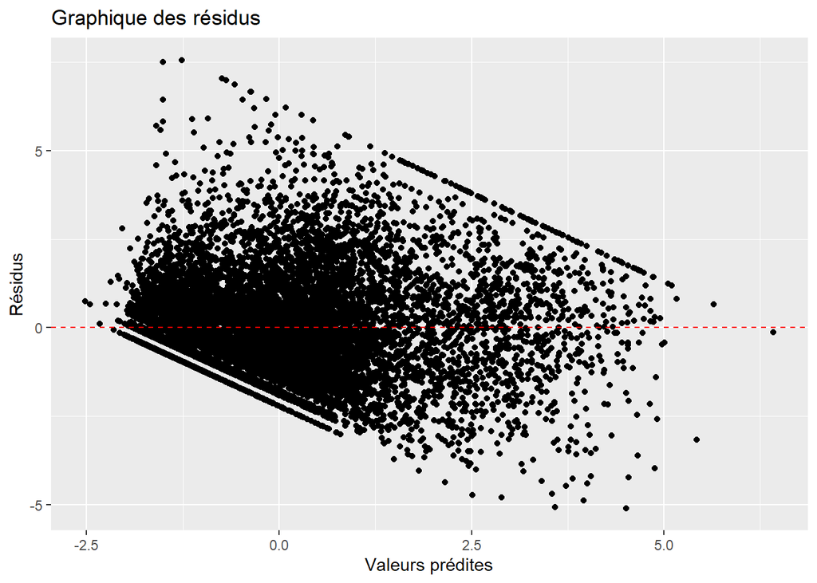

```r
# Graphique des résidus
residuals <- residuals(model_GAD)
fitted <- fitted(model_GAD)

ggplot(data = data.frame(fitted = fitted, residuals = residuals), aes(x = fitted, y = residuals)) +
  geom_point() +
  geom_hline(yintercept = 0, linetype = "dashed", color = "red") +
  labs(title = "Graphique des résidus",
       x = "Valeurs prédites",
       y = "Résidus")
```

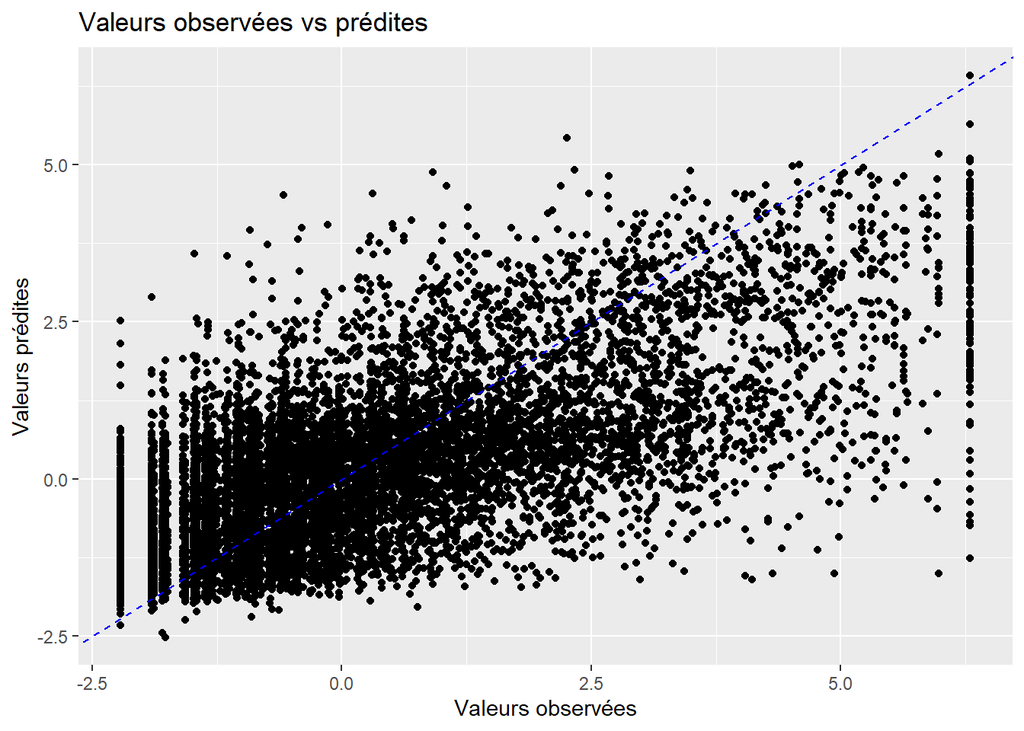

```r
# Graphique des valeurs observées vs prédites
observed <- data_with_pcaSPIN$DimGAD1

ggplot(data = data.frame(observed = observed, fitted = fitted), aes(x = observed, y = fitted)) +
  geom_point() +
  geom_abline(slope = 1, intercept = 0, linetype = "dashed", color = "blue") +
  labs(title = "Valeurs observées vs prédites",
       x = "Valeurs observées",
       y = "Valeurs prédites")
```

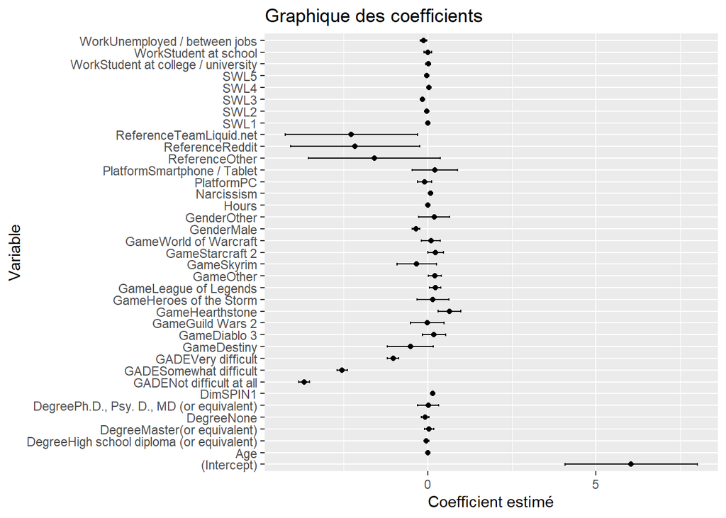

```r
# Extraire les coefficients et leurs intervalles de confiance
tidy_model <- tidy(model_GAD, conf.int = TRUE)

# Graphique des coefficients
ggplot(tidy_model, aes(x = term, y = estimate)) +
  geom_point() +
  geom_errorbar(aes(ymin = conf.low, ymax = conf.high), width = 0.2) +
  coord_flip() +
  labs(title = "Graphique des coefficients",
       x = "Variable",
       y = "Coefficient estimé")
```

```r
# Créer le modèle de régression linéaire
model_SPIN <- lm(DimSPIN1 ~ GADE + Game + SWL1 + SWL2 + SWL3 + SWL4 + SWL5 + Platform + Hours + DimGAD1 + Narcissism + Gender + Age + Work + Degree + Reference, data = data_with_pcaSPIN)

anova(model_SPIN)
```

```
## Analysis of Variance Table
##
## Response: DimSPIN1
##               Df Sum Sq Mean Sq  F value    Pr(>F)
## GADE           3  11436  3812.2 687.9854 < 2.2e-16 ***
## Game          10    103    10.3   1.8626 0.0454026 *
## SWL1           1   1882  1882.0 339.6382 < 2.2e-16 ***
## SWL2           1    193   193.4  34.9029 3.564e-09 ***
## SWL3           1    878   877.6 158.3768 < 2.2e-16 ***
## SWL4           1     31    30.5   5.5119 0.0189040 *
## SWL5           1    531   531.0  95.8315 < 2.2e-16 ***
## Platform       2     71    35.5   6.4095 0.0016518 **
## Hours          1    194   193.6  34.9374 3.501e-09 ***
## DimGAD1        1   4889  4889.1 882.3384 < 2.2e-16 ***
## Narcissism     1    137   137.3  24.7830 6.509e-07 ***
## Gender         2    789   394.6  71.2172 < 2.2e-16 ***
## Age            1    848   848.5 153.1237 < 2.2e-16 ***
## Work           3     61    20.2   3.6436 0.0121320 *
## Degree         4    108    26.9   4.8513 0.0006585 ***
## Reference      3     35    11.5   2.0796 0.1006091
## Residuals  11494  63689     5.5
## ---
## Signif. codes:  0 '***' 0.001 '**' 0.01 '*' 0.05 '.' 0.1 ' ' 1
```

```r
# Afficher un résumé du modèle
summary(model_SPIN)
```

```
##
## Call:
## lm(formula = DimSPIN1 ~ GADE + Game + SWL1 + SWL2 + SWL3 + SWL4 +
##     SWL5 + Platform + Hours + DimGAD1 + Narcissism + Gender +
##     Age + Work + Degree + Reference, data = data_with_pcaSPIN)
##
## Residuals:
##     Min      1Q  Median      3Q     Max
## -8.4886 -1.6301 -0.3184  1.4131 11.1332
##
## Coefficients:
##                                             Estimate Std. Error t value
## (Intercept)                                4.4799413  1.7137624   2.614
## GADENot difficult at all                  -0.8902131  0.1474385  -6.038
## GADESomewhat difficult                    -0.4674397  0.1384853  -3.375
## GADEVery difficult                        -0.1912655  0.1475552  -1.296
## GameDestiny                                0.0004743  0.5916389   0.001
## GameDiablo 3                               0.6709298  0.3049122   2.200
## GameGuild Wars 2                           0.4111489  0.4347911   0.946
## GameHearthstone                            0.0941926  0.2961007   0.318
## GameHeroes of the Storm                    0.4902421  0.4137415   1.185
## GameLeague of Legends                      0.1428460  0.1460849   0.978
## GameOther                                  0.2224888  0.1669942   1.332
## GameSkyrim                                 1.0235201  0.5132288   1.994
## GameStarcraft 2                            0.2502137  0.2012405   1.243
## GameWorld of Warcraft                      0.5412223  0.2508839   2.157
## SWL1                                      -0.0232830  0.0198550  -1.173
## SWL2                                      -0.0054885  0.0174693  -0.314
## SWL3                                      -0.1154351  0.0199483  -5.787
## SWL4                                      -0.0055228  0.0173505  -0.318
## SWL5                                      -0.1136386  0.0141145  -8.051
## PlatformPC                                -0.4123506  0.1846725  -2.233
## PlatformSmartphone / Tablet                0.5487195  0.5861872   0.936
## Hours                                      0.0070912  0.0016773   4.228
## DimGAD1                                    0.4342649  0.0153760  28.243
## Narcissism                                -0.0971658  0.0208460  -4.661
## GenderMale                                -1.2076151  0.0969671 -12.454
## GenderOther                               -0.1287226  0.3993564  -0.322
## Age                                       -0.0634533  0.0090457  -7.015
## WorkStudent at college / university        0.0101393  0.0648578   0.156
```

[output cut: 38 more lines]

```
## WorkStudent at school                     0.211385
## WorkUnemployed / between jobs             0.186467
## DegreeHigh school diploma (or equivalent) 0.000219 ***
## DegreeMaster(or equivalent)               0.861219
## DegreeNone                                0.000125 ***
## DegreePh.D., Psy. D., MD (or equivalent)  0.881117
## ReferenceOther                            0.511277
## ReferenceReddit                           0.853773
## ReferenceTeamLiquid.net                   0.957081
## ---
## Signif. codes:  0 '***' 0.001 '**' 0.01 '*' 0.05 '.' 0.1 ' ' 1
##
## Residual standard error: 2.354 on 11494 degrees of freedom
## Multiple R-squared:  0.2583, Adjusted R-squared:  0.256
## F-statistic: 111.2 on 36 and 11494 DF,  p-value: < 2.2e-16
```

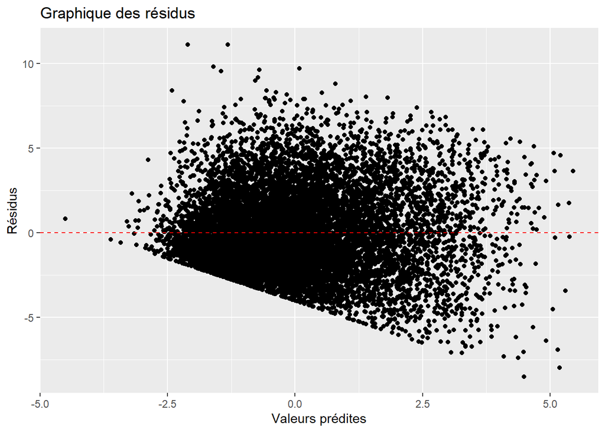

```r
# Graphique des résidus
residuals <- residuals(model_SPIN)
fitted <- fitted(model_SPIN)

ggplot(data = data.frame(fitted = fitted, residuals = residuals), aes(x = fitted, y = residuals)) +
  geom_point() +
  geom_hline(yintercept = 0, linetype = "dashed", color = "red") +
  labs(title = "Graphique des résidus",
       x = "Valeurs prédites",
       y = "Résidus")
```

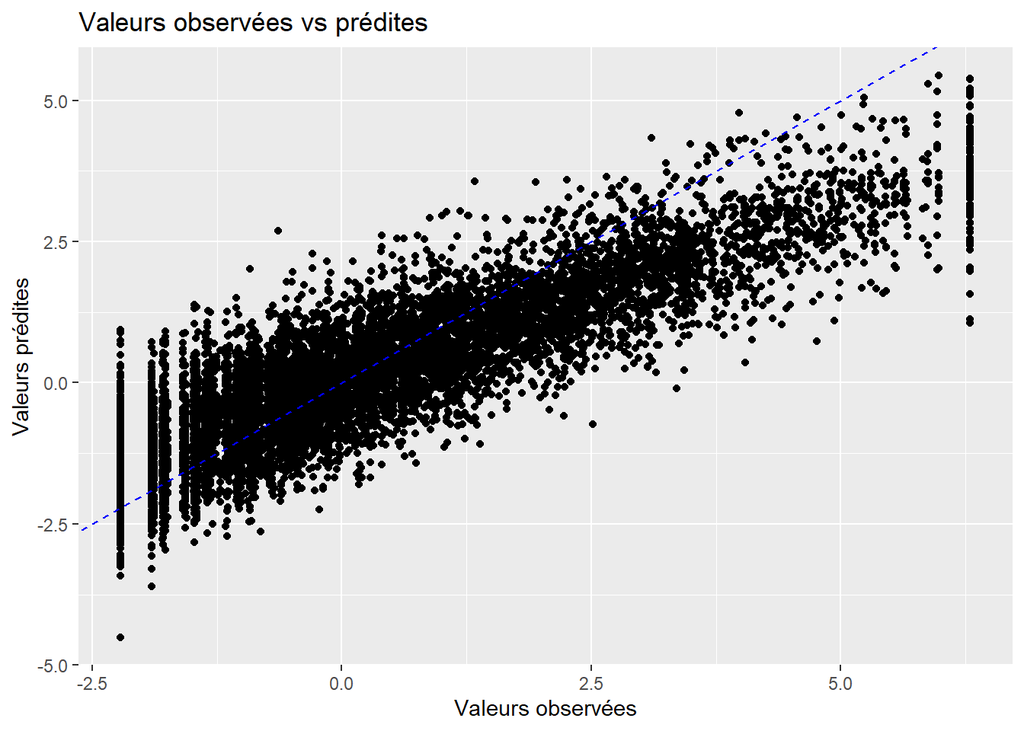

```r
# Graphique des valeurs observées vs prédites
observed <- data_with_pcaSPIN$DimGAD1

ggplot(data = data.frame(observed = observed, fitted = fitted), aes(x = observed, y = fitted)) +
  geom_point() +
  geom_abline(slope = 1, intercept = 0, linetype = "dashed", color = "blue") +
  labs(title = "Valeurs observées vs prédites",
       x = "Valeurs observées",
       y = "Valeurs prédites")
```

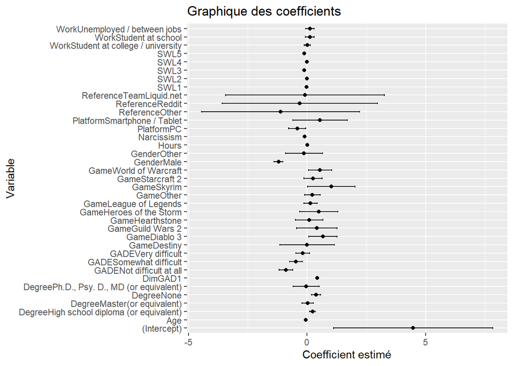

```r
# Extraire les coefficients et leurs intervalles de confiance
tidy_model <- tidy(model_SPIN, conf.int = TRUE)

# Graphique des coefficients
ggplot(tidy_model, aes(x = term, y = estimate)) +
  geom_point() +
  geom_errorbar(aes(ymin = conf.low, ymax = conf.high), width = 0.2) +
  coord_flip() +
  labs(title = "Graphique des coefficients",
       x = "Variable",
       y = "Coefficient estimé")
```

###résultat En ce qui concerne la régression de DimGAD1, les variables continues qui ont une signification positive sont SWL4, Hours, DimSPIN1 et Narcissism. Les variables continues qui ont une signification négative sont SWL2, SWL3 et SWL5. Pour ce qui est des variables catégoriques, celles qui ont une signification sont GADE, Game, Gender, Work et Reference.

Pour la régression de DimSPIN1, les variables continues qui ont une signification positive sont Hours et DimGAD1. Les variables continues qui ont une signification négative sont SWL3, SWL5, Narcissism et Age. Pour ce qui est des variables catégoriques, celles qui ont une signification sont GADE, Game, Platform, Gender, Work et Degree.

###Conclusion En somme, j’ai réussi à trouver des dimensions représentatives avec mon ACP et atteindre mes trois objectifs. L’exploration de mes données a été faite tout au long de mon projet que ce soit pour l’analyse globale, l’analyse de mon ACP ainsi que ma régression linéaire. J’ai réussi à trouver des dimensions représentatives des tests GAD et SPIN avec mon ACP et les tester sur l’ensemble de mes variables. Ma régression linéaire quant à elle a su mettre en évidence les variables qui avaient une signification dans mes données sur le sondage en lien avec l’anxiété.